# Red Wine Data Exploration by Christian Guzman

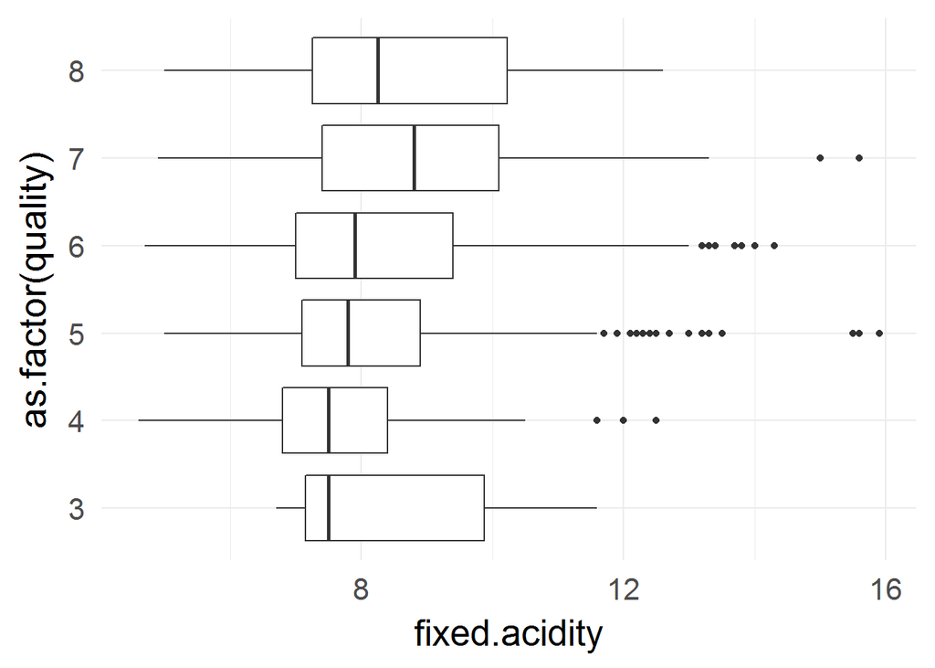

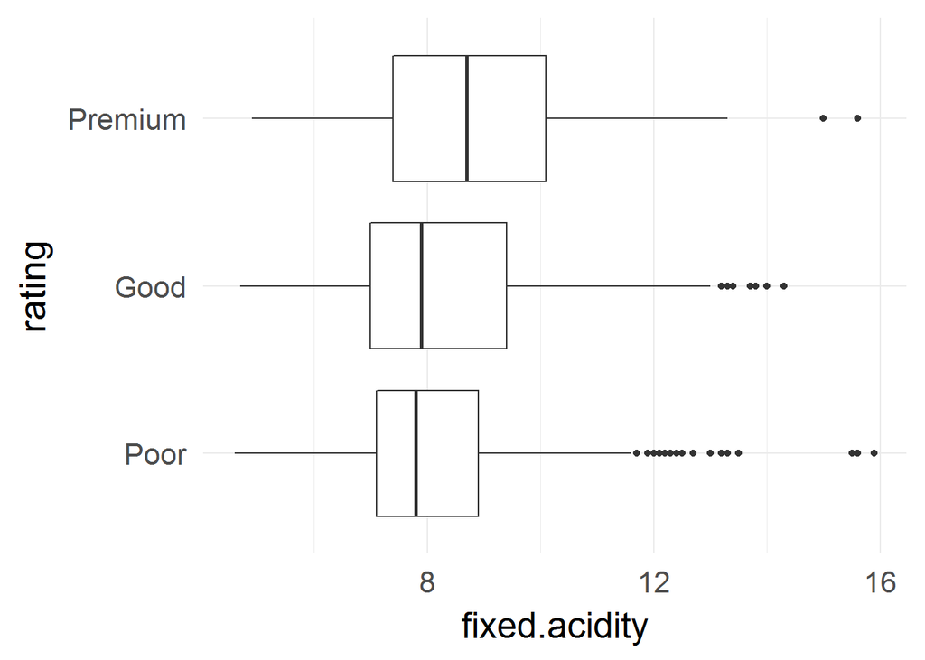

```
## [1] 0.1240516
```

```
## wine$rating: Poor
##    Min. 1st Qu.  Median    Mean 3rd Qu.    Max.
##   4.600   7.100   7.800   8.142   8.900  15.900
## --------------------------------------------------------
## wine$rating: Good
##    Min. 1st Qu.  Median    Mean 3rd Qu.    Max.
##   4.700   7.000   7.900   8.347   9.400  14.300
## --------------------------------------------------------
## wine$rating: Premium
##    Min. 1st Qu.  Median    Mean 3rd Qu.    Max.
##   4.900   7.400   8.700   8.847  10.100  15.600
```

With the box plots there is no clear visible trend.

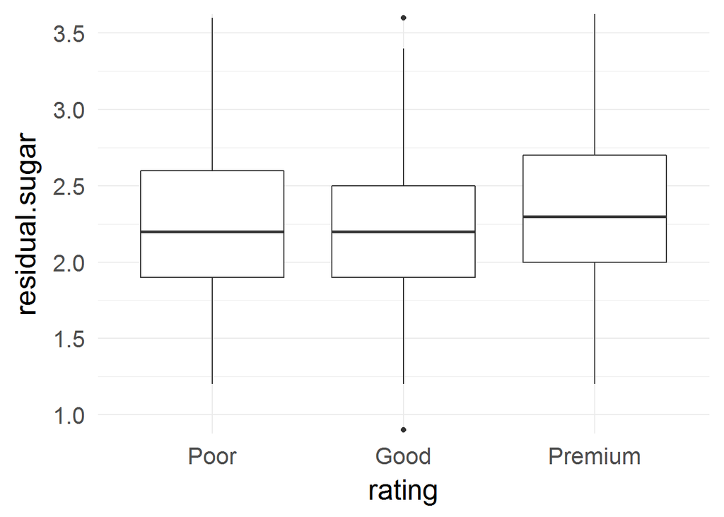

Residual sugar also does not show strong correlation with quality rating, as I thought it would initially.

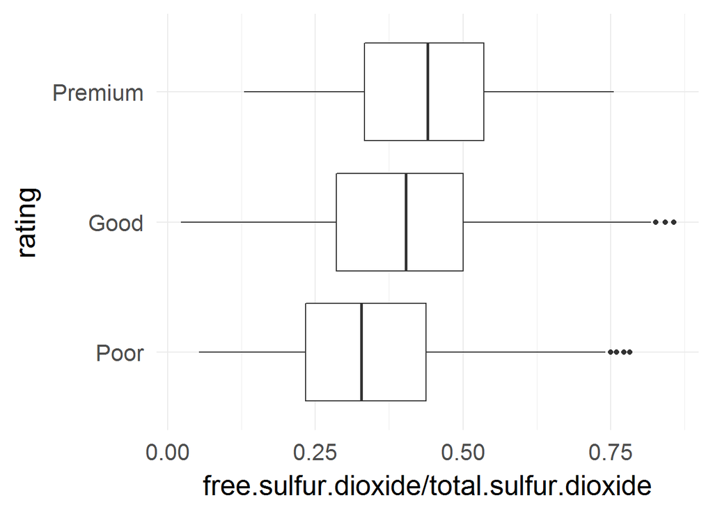

# Bivariate Analysis

### Talk about some of the relationships you observed in this part of the investigation. How did the feature(s) of interest vary with other features in the dataset?

The main feature of interest, quality was most strongly correlated with alcohol and volatile acidity.

There was no clear visible trend for fixed acidity and rating nor was there for residual sugar and rating.

Better wines tend to have higher proportion of free sulfur dioxide.

### Did you observe any interesting relationships between the other features (not the main feature(s) of interest)?

As fixed acidity content increases citric acid and density also tend to increase. But as fixed acidity increases pH value tends to decrease, indicating an increase in acidity.

Citric acid is strongly correlated with fixed acidity and volatile acidity. The pearson scores are 0.67 and -0.55 respectively.

### What was the strongest relationship you found?

Fixed acidity was negatively and strongly correlated with pH, positively correlated with citric acid and density.

free sulfur dioxide was also strongly and positively correlated with total sulfur dioxide but this is to be expected since free SO2 is a portion of total SO2.

From this exploration and analysis I might not want to use fixed acidity with pH, citric acid, or density to reduce colinearity between the explanatory variables to better understand the relationships between the independent variable and the dependent variables.

# Multivariate Plots Section

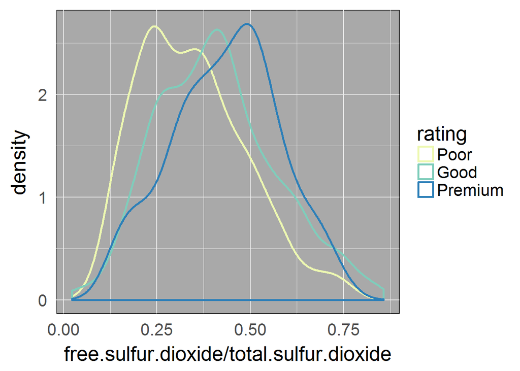

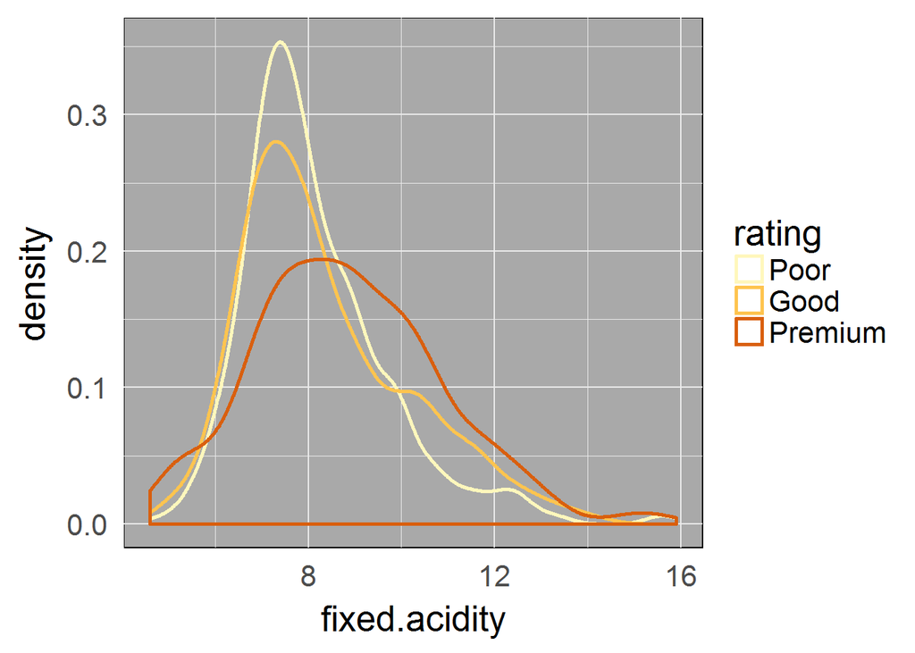

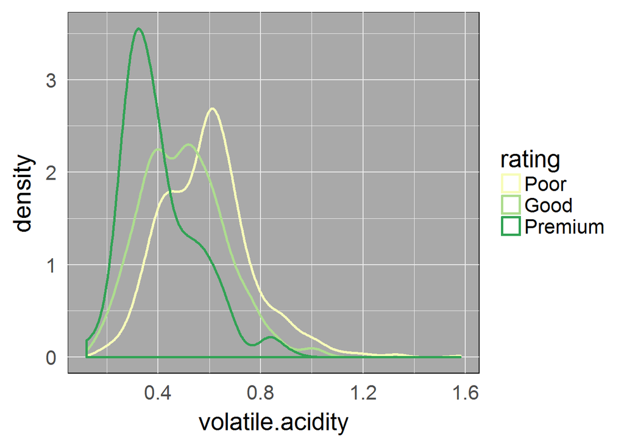

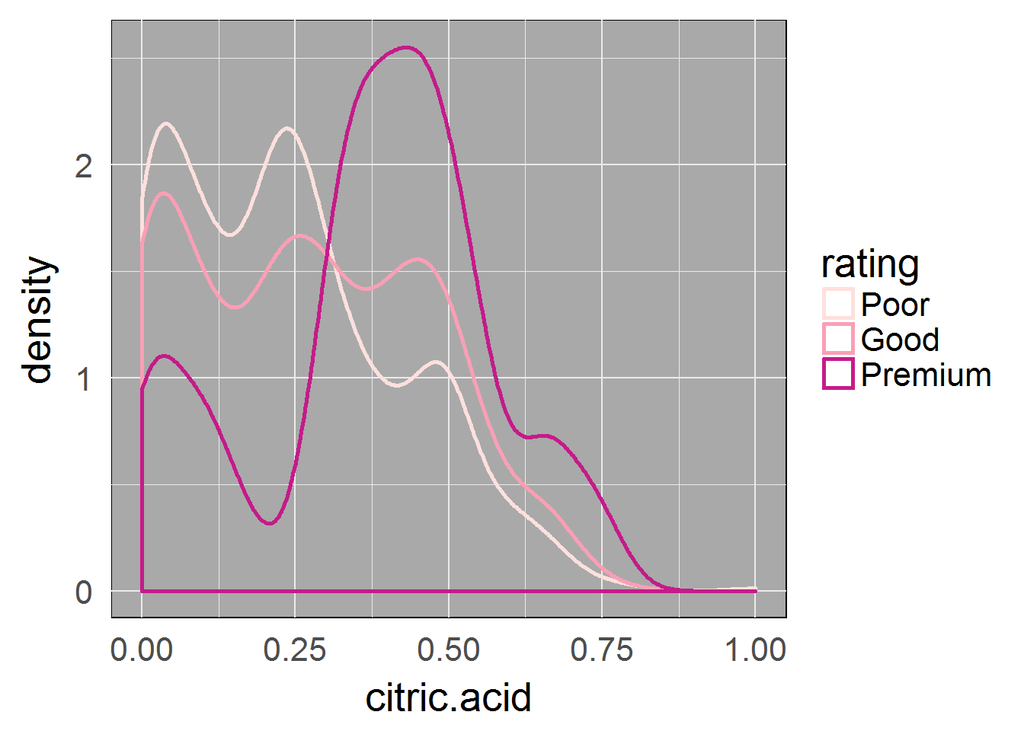

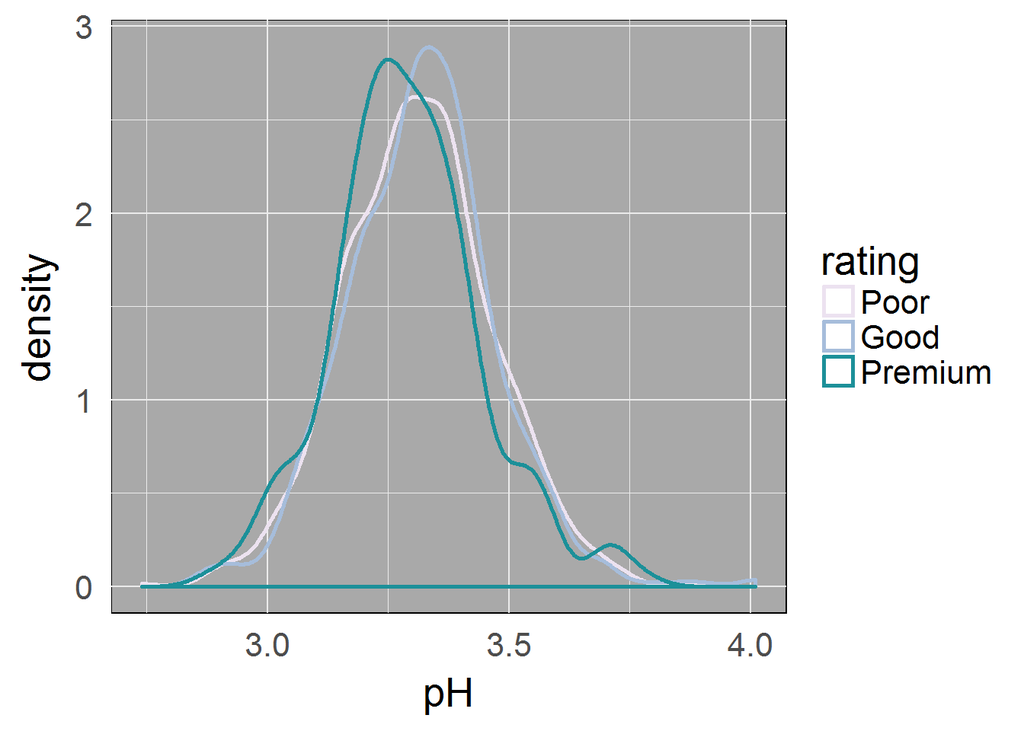

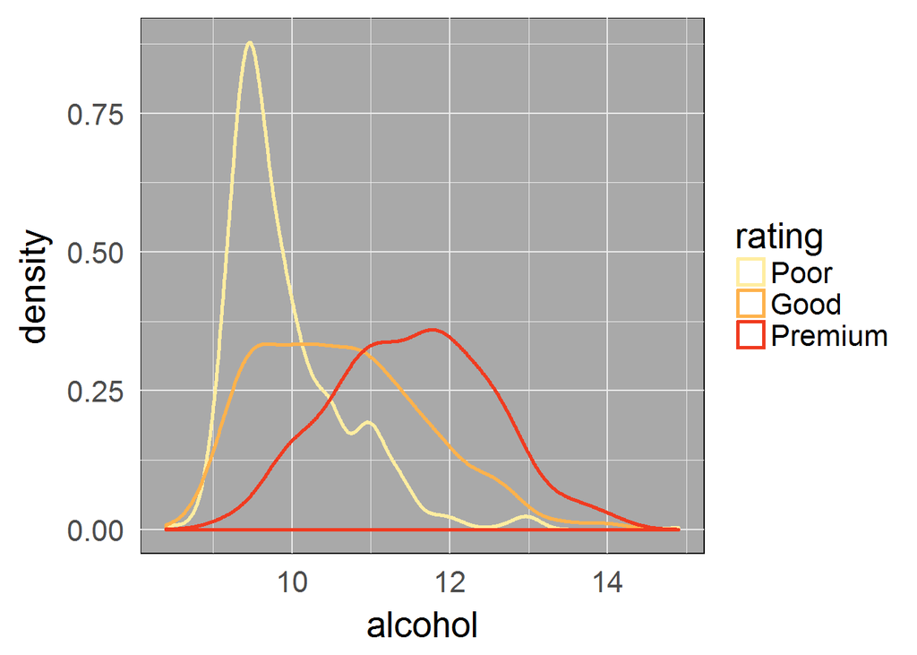

These density plots show the trends of each feature by wine quality rating group. The most obvious trends being free SO2 proportion, volatile acidity, citric acid and alcohol.

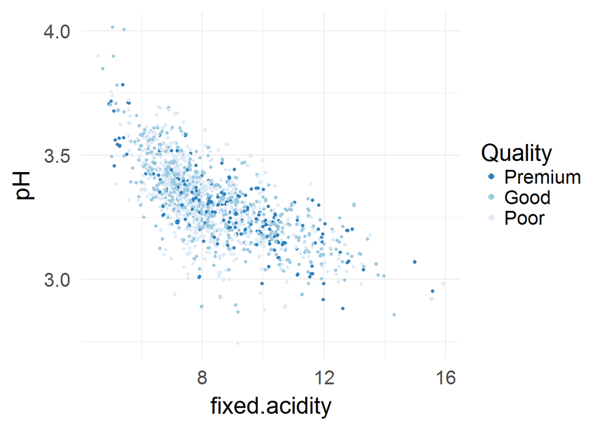

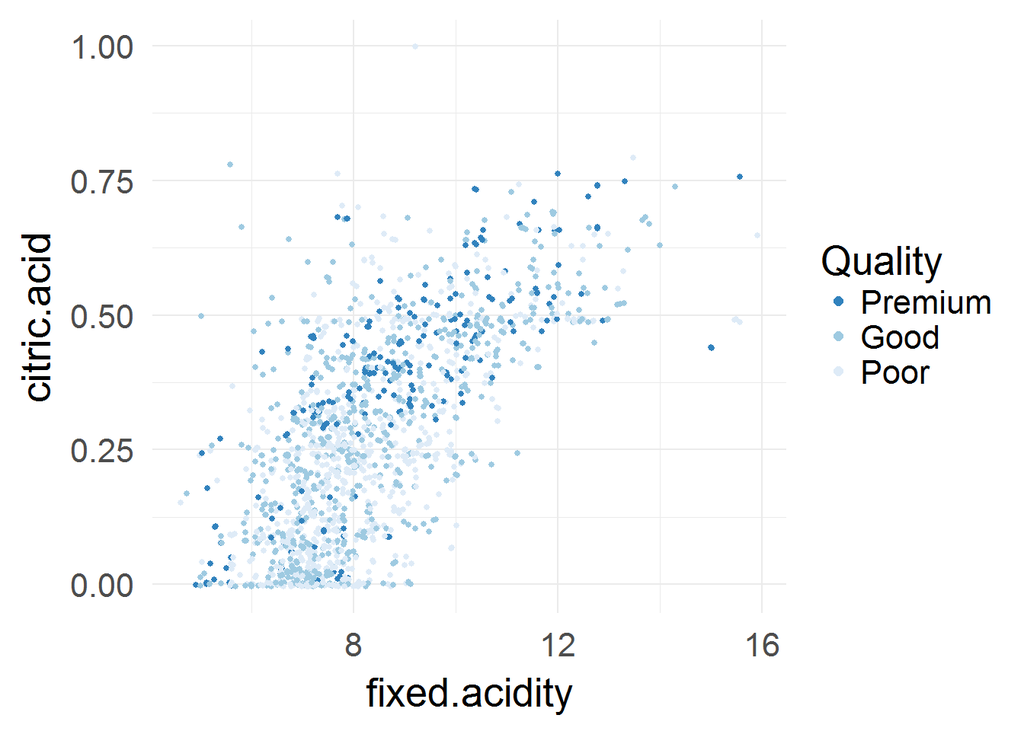

There is a cluster of premium rated wines with more than 0.25 of citric acid and with more than 8 grams/cubic decimeter of fixed acidity.

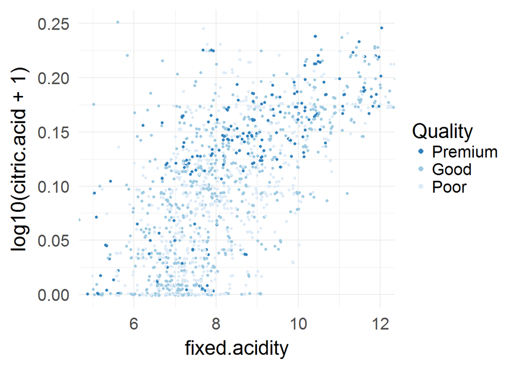

Same graph as above with log of citric acid to lessen the effect of outliers.

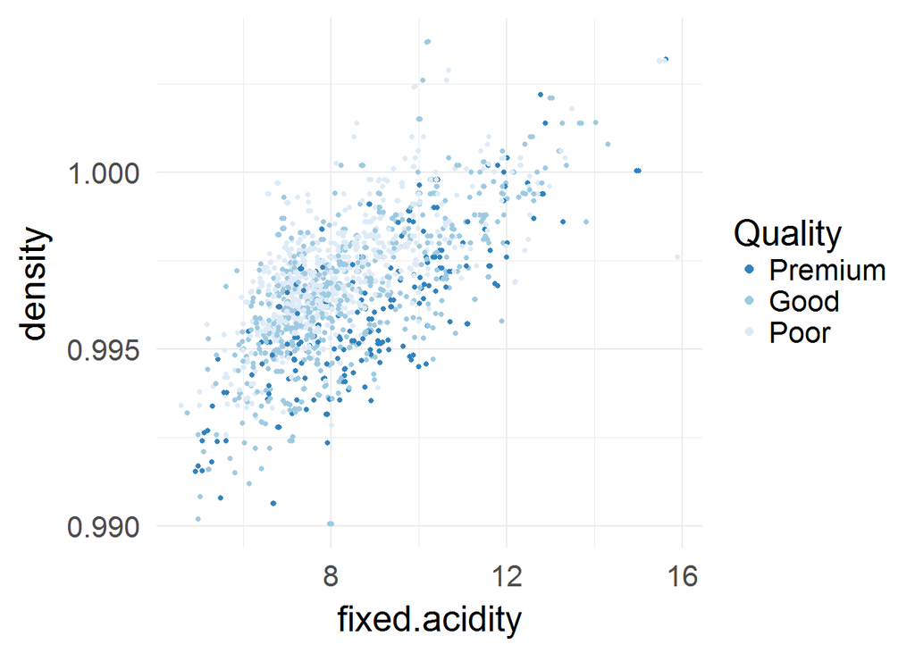

Higher quality wines tend to have lower density.

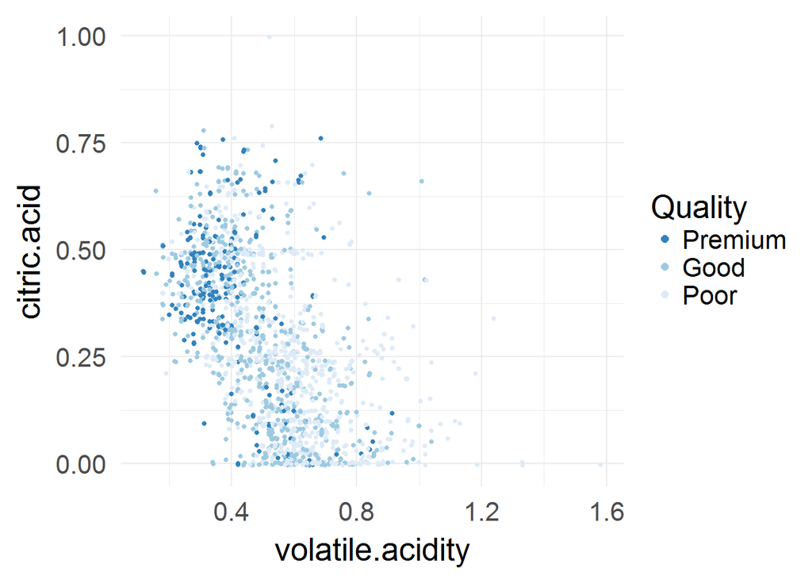

There is a concentration of premium wines on the lower end of volatile acidity concentration and with citric acid between .25 and .75.

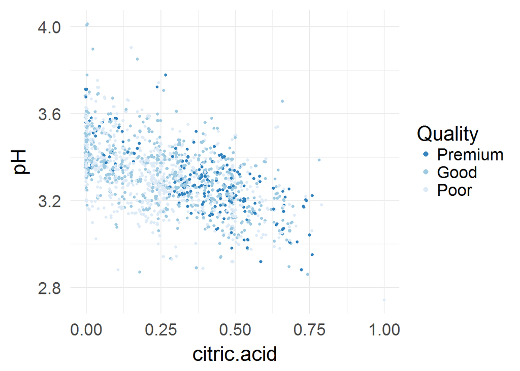

There is a cluster of premium wines with lower pH and higher citric acid concentration.

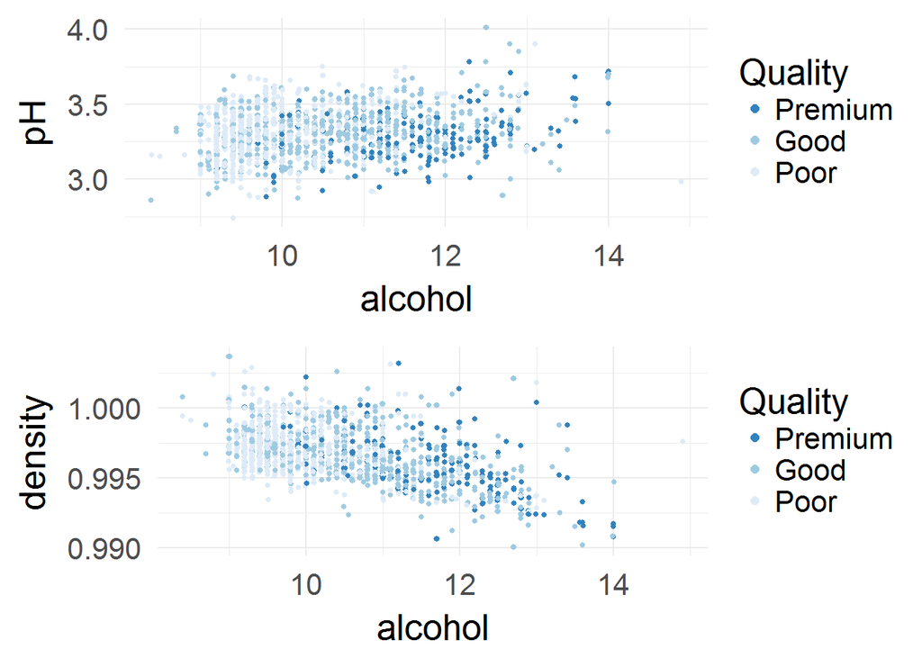

These two scatter plots show what we know about higher rated wines having higher alcohol content. The trend does not seem in anyway influenced by the variables pH and density.

```
##  Hlavac, Marek (2015). stargazer: Well-Formatted Regression and Summary Statistics Tables.
```

```
##  R package version 5.2. http://CRAN.R-project.org/package=stargazer
```

```
##
##    Poor    Good Premium
##     744     638     217
```

```
## Call:
## multinom(formula = out ~ volatile.acidity + alcohol + citric.acid +
##     freeSO2, data = mydata)
##
## Coefficients:
##         (Intercept) volatile.acidity   alcohol citric.acid  freeSO2
## Good      -7.104562        -3.223543 0.7922975  -0.2983047 1.771429
## Premium  -16.144892        -5.624384 1.5061294   1.5324275 3.029272
##
## Std. Errors:
##         (Intercept) volatile.acidity    alcohol citric.acid   freeSO2
## Good      0.7768862        0.4431094 0.07199729   0.3918782 0.4196536
## Premium   1.2231391        0.7660806 0.10032593   0.5980129 0.6514164
##
## Residual Deviance: 2537.765
## AIC: 2557.765
```

Using this model based on the scatter plot, we can see that there is a decrease in the log odds associated with the volatile acidity variable for both “Good” vs. “Poor” wine groups.

The freeSO2 variable is the percentage of free sulfur dioxide compared with the total amount of sulfur dioxide.

```r
# p-values
stargazer(m1, type = "text")
```

```
##
## ==============================================
##                       Dependent variable:
##                   ----------------------------
##                        Good         Premium
##                        (1)            (2)
## ----------------------------------------------
## volatile.acidity    -3.224***      -5.624***
##                      (0.443)        (0.766)
##
## alcohol              0.792***      1.506***
##                      (0.072)        (0.100)
##
## citric.acid           -0.298        1.532**
##                      (0.392)        (0.598)
##
## freeSO2              1.771***      3.029***
##                      (0.420)        (0.651)
##
## Constant            -7.105***     -16.145***
##                      (0.777)        (1.223)
##
## ----------------------------------------------
## Akaike Inf. Crit.   2,557.765      2,557.765
## ==============================================
## Note:              *p<0.1; **p<0.05; ***p<0.01
```

```r
# Easier interpretation using relative risk ratios
m.rrr = exp(coef(m1))
m.rrr
```

```
##          (Intercept) volatile.acidity  alcohol citric.acid  freeSO2
## Good    8.213496e-04      0.039813765 2.208464   0.7420752  5.87925
## Premium 9.735597e-08      0.003608785 4.509243   4.6294013 20.68218
```

Taking the exponential of the coefficients will allow for easier interpretation of the logit coefficients.

# Multivariate Analysis

### Talk about some of the relationships you observed in this part of the investigation. Were there features that strengthened each other in terms of looking at your feature(s) of interest?

Yes, Using scatter plots comparing features with quality rating as the color factor I was able to view clusters of wine groups. The best visualizations for this where: Fixed acidity vs. citric acid, fixed acidity vs.density, volatile acidity vs. citric acid, and citric acid vs. pH. I knew from this that I should try to use most of these features in any model.

### Were there any interesting or surprising interactions between features?

Yes I was surprised that citric acid and volatile acidity modeled wine quality groups pretty well. Citric acid was more important than I thought it would be before starting the analysis.

### Did you create any models with your dataset? Discuss the strengths and limitations of your model.

I created a multinomial logit model. It is good for cases when the outcome variable is categorical with more than 2 levels.

The model was able to generate coeficients that supported my explorations of the the data. Volatile acidity had a negative coefficient, and alcohol a positive one, for example. From this I was able to interpret how the model would use the features in computing log odds for predictions.

The model however had a large Residual Deviance value of 2537.765, for a multinomial logit the deviance is preferred to be smaller. This could be that the features were not the best choice or there are still features that are not in the data that assist in creating a model.

# Final Plots and Summary

### Plot One

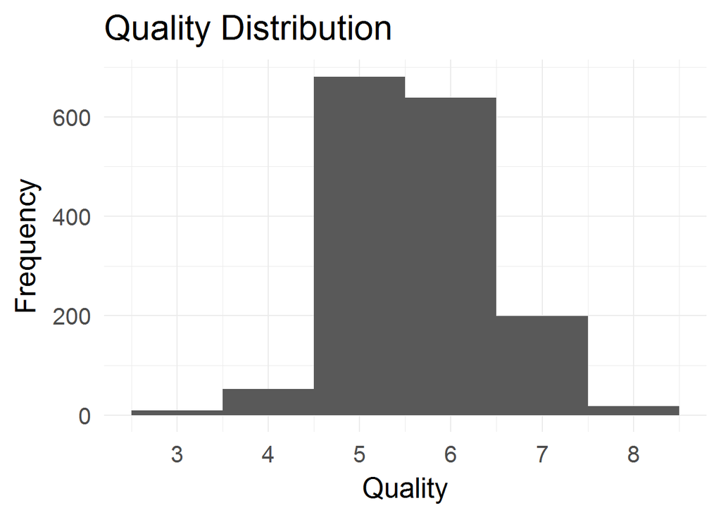

### Description One

From this visualization it was observed that most of the wines were rated 5 or 6. Very few other ratings were given relatively. Due to this the decision was made to label wines with rating 3 to 5 as “Poor”, 6 as “Good”, and 7 to 8 as “Premium” wines.

### Plot Two

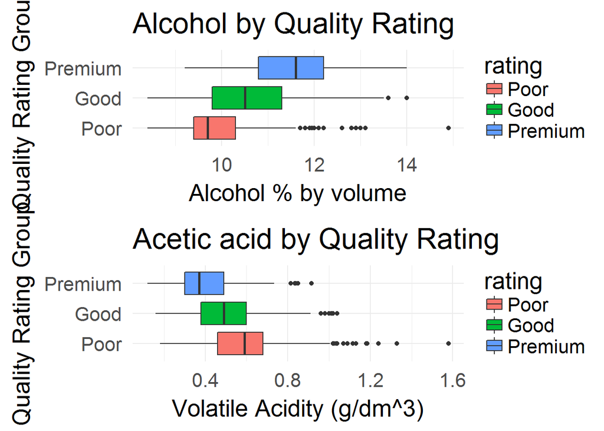

### Description Two

Higher rated wines tend to have higher alcohol content and less acetic acid. I expected this trend because it was stated in data set text file that volatile acidity can contribute to a strong vinegar taste in the wine. While higher alcohol seems to be an important characteristic to wines.

### Plot Three

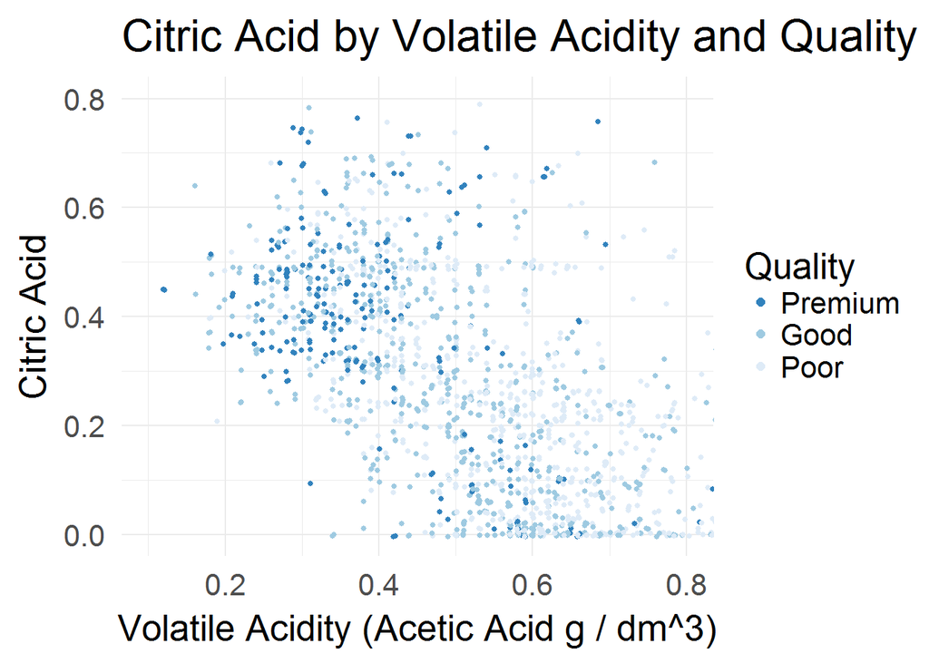

### Description Three

Premium wines cluster at higher citric acid content and lower acetic acid content.

# Reflection

The wine data set contains observations on nearly 1600 red wines, and initially contained 13 features with no missing data. I explored the structure of the data and identified the most important features and those that would not be important to the analysis. I saw that the “Quality” were ratings made by wine tasting experts. The minimum and maximum values were 3 and 8 respectively. I combined the the ratings into appropriate bins to make up for small amount of data for certain ratings like, 3, 4 and 8. By combining the ratings into “Poor”, “Good”, and “Premium” groups I was able to make data readings more legible.

The outcome variable Quality was most strongly correlated with Alcohol and Volatile Acidity features with pearson scores0.5 and -0.6 respectively. Of all the pairs of correlations the strongest pearson scores were between Fixed Acidity vs. pH, Citric Acid, and Density.

A limitation of this dataset is there are so few ratings except for 5 and 6, making me have to bin the data. I had to make the decision of which ratings would be poor and which would be best without the domain knowledge. I also think this data could benefit from a machine learning algorithm and feature selection to create a stronger model. Despite that with the multinomial logit model I identified features of significance (alcohol, volatile acidity, citric acid, and freeSo2).